# lecture_9

Tiffany Luong

2/5/2020

https://bioboot.github.io/bggn213_W20/class-material/lab-8-bggn213.html

## K-means clustering

Let’s try the `kmeans()` function in R to cluster some made-up example data.

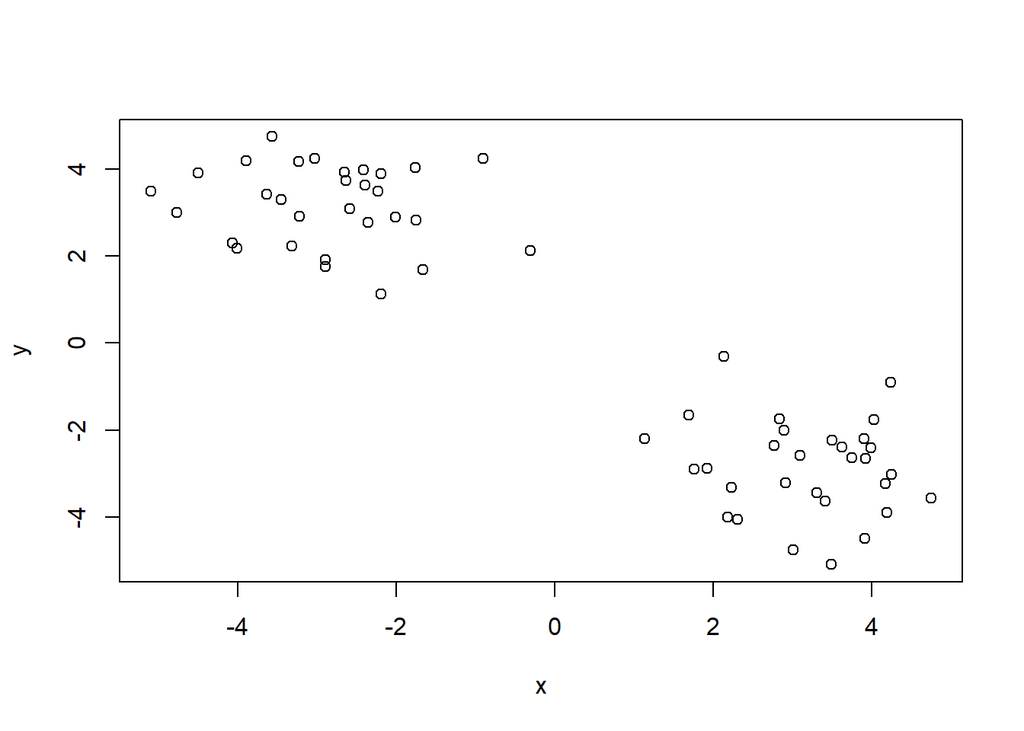

```r
# Generate some example data for clustering

#30 points with a mean of -3. The second rnorm generates 30 points with a mean of +3.

tmp <- c(rnorm(30,-3), rnorm(30,3))

x <- cbind(x=tmp, y=rev(tmp))

plot(x)
```

Use the kmeans() function settkming k to 2 and nstart = 20.

```r
km <- kmeans(x, centers = 2, nstart = 20)
```

Inspect/print the results

```r
km
```

```
## K-means clustering with 2 clusters of sizes 30, 30
##
## Cluster means:
##           x         y
## 1  3.179219 -2.853606
## 2 -2.853606  3.179219
##
## Clustering vector:
##  [1] 2 2 2 2 2 2 2 2 2 2 2 2 2 2 2 2 2 2 2 2 2 2 2 2 2 2 2 2 2 2 1 1 1 1 1 1 1 1
## [39] 1 1 1 1 1 1 1 1 1 1 1 1 1 1 1 1 1 1 1 1 1 1
##
## Within cluster sum of squares by cluster:
## [1] 59.06089 59.06089
##  (between_SS / total_SS =  90.2 %)
##
## Available components:
##
## [1] "cluster"      "centers"      "totss"        "withinss"     "tot.withinss"
## [6] "betweenss"    "size"         "iter"         "ifault"
```

What is in the output object `km`? I can use the `attributes()` function to find this info. :-)

```r
attributes(km)
```

```
## $names
## [1] "cluster"      "centers"      "totss"        "withinss"     "tot.withinss"
## [6] "betweenss"    "size"         "iter"         "ifault"
##
## $class
## [1] "kmeans"
```

Q. How many points are in each cluster?

```r
km$size
```

```
## [1] 30 30
```

Q. What ‘component’ of your result object details - cluster size? see above.

- cluster assignment/membership?

```r
km$cluster
```

```
##  [1] 2 2 2 2 2 2 2 2 2 2 2 2 2 2 2 2 2 2 2 2 2 2 2 2 2 2 2 2 2 2 1 1 1 1 1 1 1 1
## [39] 1 1 1 1 1 1 1 1 1 1 1 1 1 1 1 1 1 1 1 1 1 1
```

Let’s check how many 2’s and 1’s are in this vector with the `table()` function.

```r
table(km$cluster)
```

```
##
##  1  2
## 30 30
```

- cluster center?

```r
km$centers
```

```
##           x         y
## 1  3.179219 -2.853606
## 2 -2.853606  3.179219
```

Plot x colored by the kmeans cluster assignment and add cluster centers as blue points.

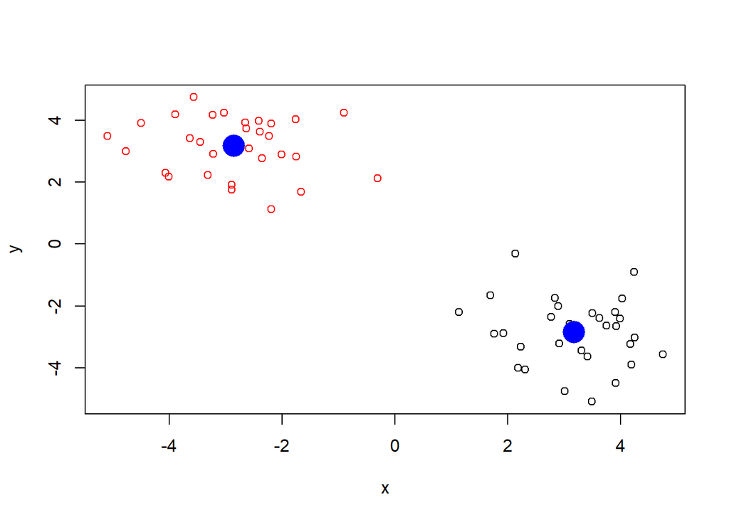

```r
#c(rep("red", 30), rep("blue",30))

plot(x, col=km$cluster)
points(km$centers, col="blue", pch=16, cex=3)
```

## Hierarchical clustering in R

The `hclust()` function is the main Hierarchical clustering method in R and it **must** be passed a *distance matrix* as input, not your raw data!

```r
hc <- hclust(dist(x))

hc
```

```
##
## Call:
## hclust(d = dist(x))
##
## Cluster method   : complete
## Distance         : euclidean
## Number of objects: 60
```

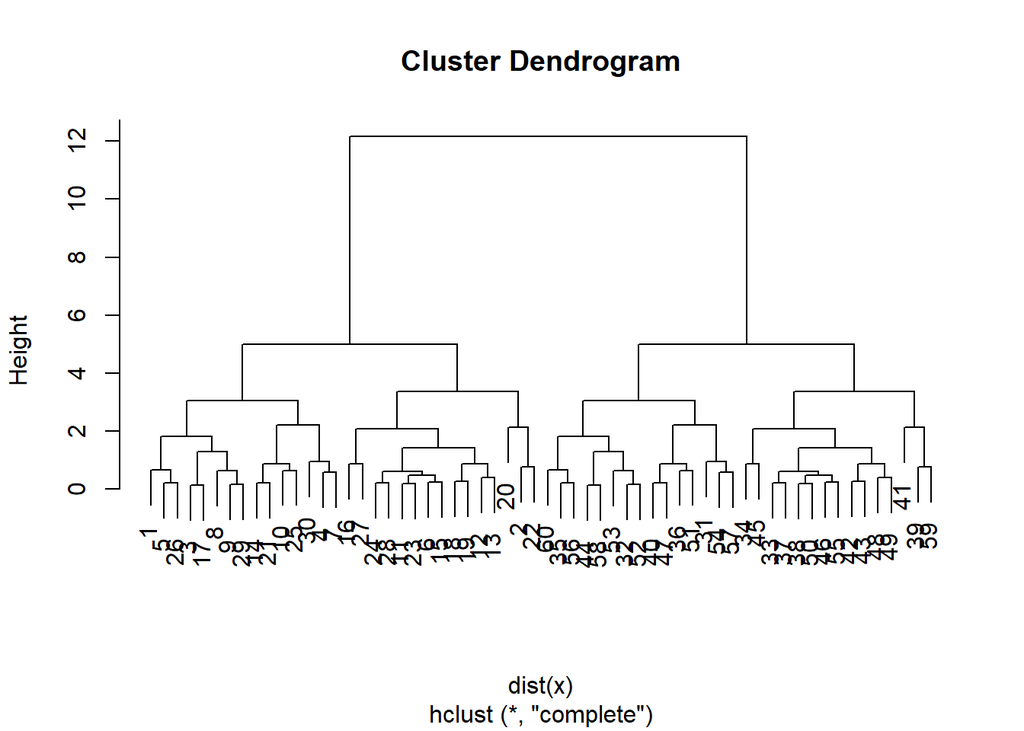

```r
plot(hc)
```

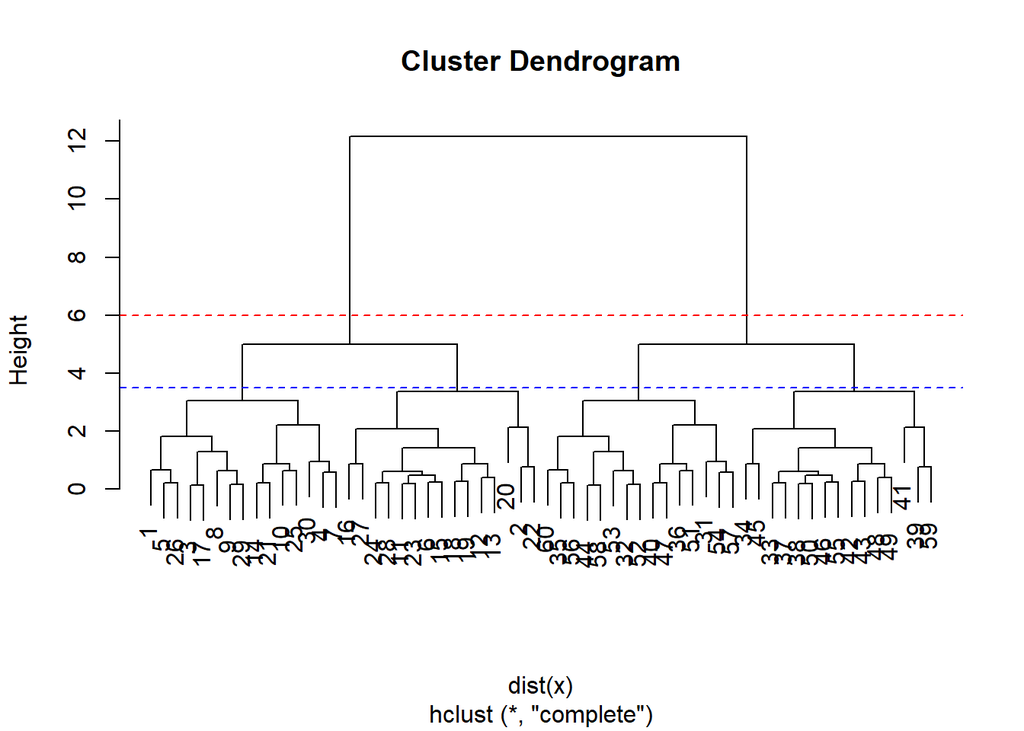

```r
plot(hc)
abline(h=6, col="red", lty=2)
abline(h=3.5, col="blue", lty=2)
```

```r
cutree(hc, h=6)
```

```
##  [1] 1 1 1 1 1 1 1 1 1 1 1 1 1 1 1 1 1 1 1 1 1 1 1 1 1 1 1 1 1 1 2 2 2 2 2 2 2 2
## [39] 2 2 2 2 2 2 2 2 2 2 2 2 2 2 2 2 2 2 2 2 2 2
```

```r
table(cutree(hc, h=3.5))
```

```
##
##  1  2  3  4
## 15 15 15 15
```

You can also ask `cutree()` for the `k` number of groups that you want.

```r
cutree(hc, k=5)
```

```
##  [1] 1 2 1 1 1 2 1 1 1 1 2 2 2 1 2 2 1 2 2 2 1 2 2 2 1 1 2 2 1 1 3 3 4 4 3 3 4 4
## [39] 5 3 5 4 4 3 4 4 3 4 4 4 3 3 3 3 4 3 3 3 5 3
```

## Data clustering.

Step 1. Generate some example data for clustering

```r
x <- rbind(
matrix(rnorm(100, mean=0, sd=0.3), ncol = 2), # c1
matrix(rnorm(100, mean=1, sd=0.3), ncol = 2), # c2
matrix(c(rnorm(50, mean=1, sd=0.3), # c3
rnorm(50, mean=0, sd=0.3)), ncol = 2))
colnames(x) <- c("x", "y")
```

Step 2. Plot the data without clustering

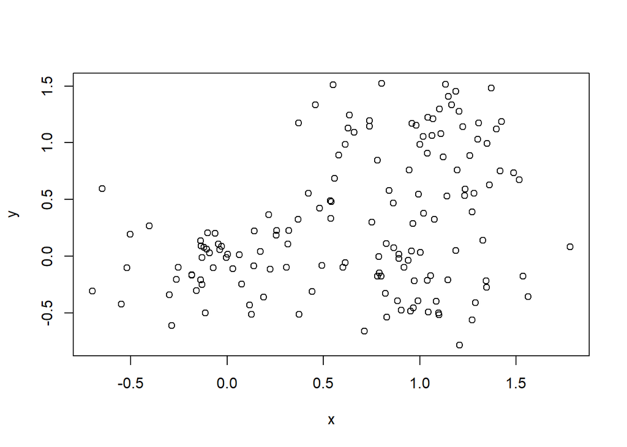

```r
plot(x)
```

Step 3. Generate colors for known clusters

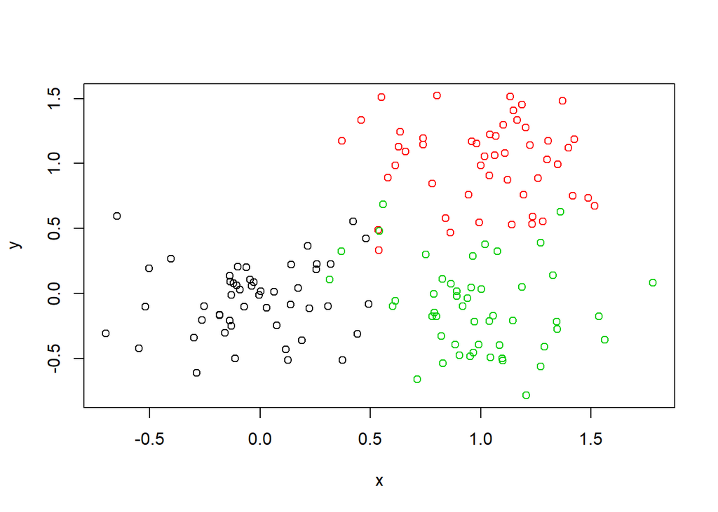

```r
# (just so we can compare to hclust results)
col <- as.factor( rep(c("c1","c2","c3"), each=50) )
plot(x, col=col)
```

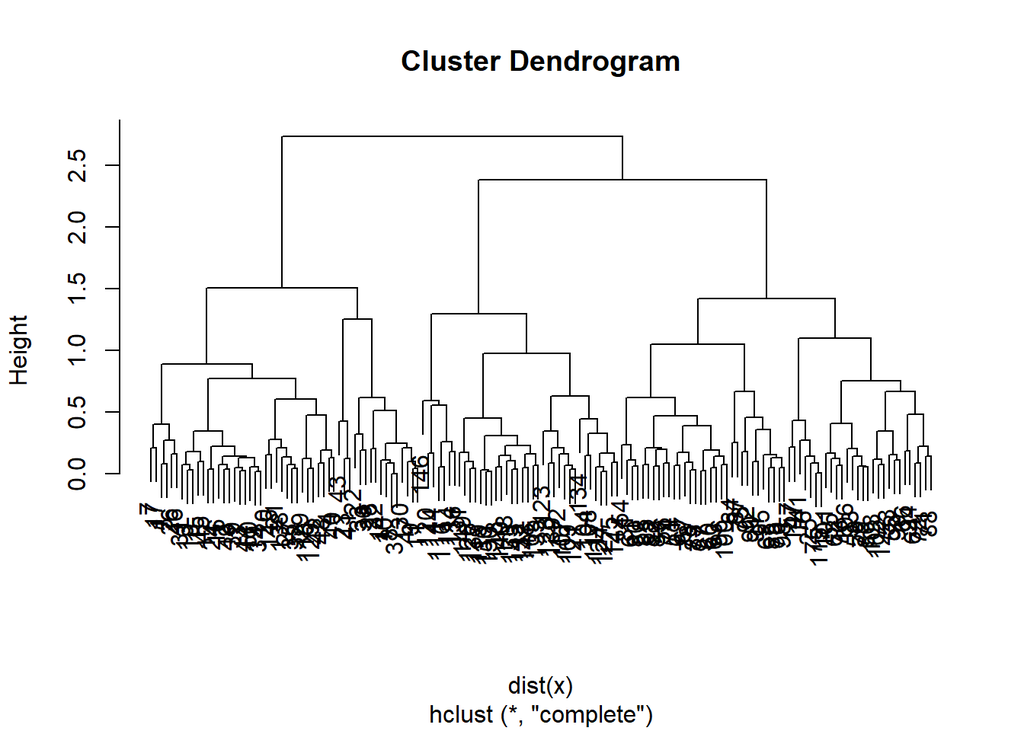

```r
hc <- hclust(dist(x))

plot(hc)
```

```r
grps3 <- cutree(hc, k=3)

grps3
```

```
##   [1] 1 1 1 1 1 2 1 1 1 1 1 1 1 1 1 1 1 1 1 1 1 1 1 1 2 1 1 1 1 1 1 1 1 1 1 1 1
##  [38] 1 1 1 1 1 1 1 1 1 1 1 1 1 2 2 2 2 2 2 2 2 2 2 2 2 2 2 2 2 2 2 2 2 2 2 2 2
##  [75] 2 2 2 2 2 2 2 2 2 2 2 2 2 2 2 2 2 2 2 2 2 2 2 2 2 2 2 2 2 3 3 2 3 3 3 1 3
## [112] 3 3 3 2 3 3 3 3 3 3 2 3 3 3 3 3 3 1 3 3 3 3 3 3 3 3 1 3 3 2 3 3 3 1 3 2 3
## [149] 3 3
```

```r
table(grps3)
```

```
## grps3
##  1  2  3
## 52 60 38
```

Q. How does this compare to your known ‘col’ groups?

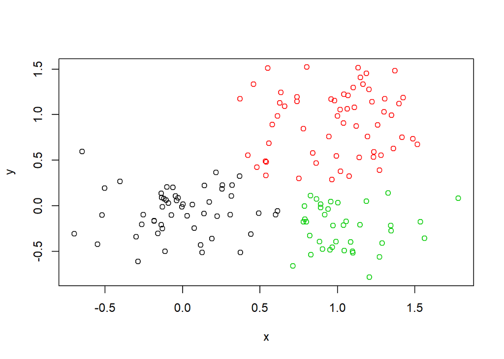

```r
plot(x, col=grps3)
```

We can use a cross table to look at the data we just generated. Cluster from k=3 compared to the original data “col”. Think of it as looking at “true positives” vs. “false positives”.

```r
table(grps3, col)
```

```
##      col
## grps3 c1 c2 c3
##     1 48  0  4
##     2  2 50  8
##     3  0  0 38
```